# Final Project

2024-05-17

Bjorn McGrady

Project Proposal Abstract

This project aims to analyze the “Winningest Cities in Sports” dataset to identify trends and patterns in sports championships across various cities and sports. We will explore which cities have the most championships, the distribution of championships over time, and the dominance of particular sports in certain regions.

Keywords

Sports analytics, championships, data visualization, city analysis, trend analysis

Introduction

The objective of this project is to explore the distribution of sports championships across different cities in the United States. By analyzing the dataset, we aim to answer the following research questions: Which cities have the highest number of sports championships? How has the distribution of championships changed over time? Are there specific sports that dominate certain cities? What is the average number of championships per city? How do the runner-up statistics compare to the winning statistics? These questions are motivated by a desire to understand the geographical dominance in sports and the factors contributing to a city’s success in sports championships. This analysis is important as it can provide insights for sports franchises, city planners, and sports enthusiasts about the historical and potential future trends in sports success across different regions.

Related Work

Several studies and articles have explored the relationship between cities and their sports success. For example, a study by Smith et al. (2020) examined the economic impact of sports championships on host cities, highlighting the significance of sports in urban development . Another article by Johnson (2019) analyzed the correlation between a city’s population and its success in various sports, providing a demographic perspective on sports dominance . Lastly, a report by ESPN (2018) offered a comprehensive overview of the historical success of various sports teams across major U.S. cities, serving as a foundational reference for our analysis .

The Dataset

The dataset used for this project is the “Winningest Cities in Sports” dataset from Data.World. This dataset was collected by The Pudding and includes information on sports championships across various cities.

Source: The Pudding - Winningest Cities in Sports Collector: The Pudding Collection Method: Data was gathered from various sports league records and archives. Purpose: The dataset was collected to provide an overview of sports championship distributions across U.S. cities. Observations: The dataset includes over 200 observations. Features: The dataset contains columns such as index, year, level, sport, winner, winner_metro, runner_up, runner_up_metro, final_four3, final_four3_metro, final_four4, and final_four4_metro. Ethical Considerations: While the dataset does not directly pose significant ethical concerns, it is crucial to consider the potential biases in data collection, such as incomplete records or regional preferences in sports coverage.

Limitations

The primary limitation of the dataset is that it might not include every minor league or less popular sports events, potentially skewing the analysis towards major sports leagues. Additionally, historical data accuracy might vary, leading to inconsistencies in the dataset.

Implications

Assuming the research questions are answered, the findings can have significant implications for technologists, designers, and policymakers. Technologists can leverage this data to build predictive models for sports outcomes based on historical trends. Designers can create more engaging and informative visualizations to represent sports dominance and trends. Policymakers can use the insights to promote sports development in less dominant regions, fostering a more balanced growth of sports culture nationwide.

Despite these challenges, this project aims to provide meaningful insights into the distribution of sports championships across U.S. cities, contributing valuable information to the field of sports analytics.

```r
# Load the data
library(tidyverse)
data <- read_csv("titles.csv")
data
```

```
## # A tibble: 996 × 12
##    index  year level   sport       winner winner_metro runner_up runner_up_metro
##    <dbl> <dbl> <chr>   <chr>       <chr>  <chr>        <chr>     <chr>
##  1     1  1870 college Football (… Princ… Princeton, … <NA>      <NA>
##  2     2  1870 college Football (… Rutge… New Brunswi… <NA>      <NA>
##  3     3  1871 college Football (… Princ… Princeton, … <NA>      <NA>
##  4     4  1873 college Football (… Princ… Princeton, … <NA>      <NA>
##  5     5  1874 college Football (… Princ… Princeton, … <NA>      <NA>
##  6     6  1875 college Football (… Yale … New Haven, … <NA>      <NA>
##  7     7  1876 college Football (… Harva… Greater Bos… <NA>      <NA>
##  8     8  1877 college Football (… Yale … New Haven, … <NA>      <NA>
##  9     9  1878 college Football (… Yale … New Haven, … <NA>      <NA>
## 10    10  1879 college Football (… Princ… Princeton, … <NA>      <NA>
## # ℹ 986 more rows
## # ℹ 4 more variables: final_four3 <chr>, final_four3_metro <chr>,
## #   final_four4 <chr>, final_four4_metro <chr>
```

```r
# Load necessary libraries
library(dplyr)
library(tidyverse)
```

```r
# Define the summary information function
source("summary_info.R")
```

```
## $num_observations
## [1] 996
##
## $num_features
## [1] 12
##
## $city_with_most_championships
## [1] "Greater Los Angeles, CA"
##
## $total_championships_for_top_city
## [1] 74
##
## $avg_championships_per_city
## [1] 8.163934
##
## $num_sports
## [1] 12
##
## $time_range
## [1] 1870 2018
```

```r
source("aggregate_table.R")
```

```
## # A tibble: 254 × 3
## # Groups:   City [122]
##    City                    Sport        `Total Championships`
##    <chr>                   <chr>                        <dbl>
##  1 New York Metro Area     MLB                             35
##  2 Montreal, QC            NHL                             27
##  3 Toronto, ON             CFL                             24
##  4 Greater Raleigh, NC     Soccer (W)                      21
##  5 Greater Los Angeles, CA Baseball (M)                    18
##  6 New Haven, CT           Football (M)                    18
##  7 Greater Boston, MA      NBA                             17
##  8 Hamilton, ON            CFL                             15
##  9 Princeton, NJ           Football (M)                    15
## 10 Tuscaloosa, AL          Football (M)                    15
## # ℹ 244 more rows
```

I included this table to give insights as to which sports are winning the most championships within each city. This table revealed that Baseball championships in New York was the highest amount of championships won from a single sport within any city apart of the U.S.

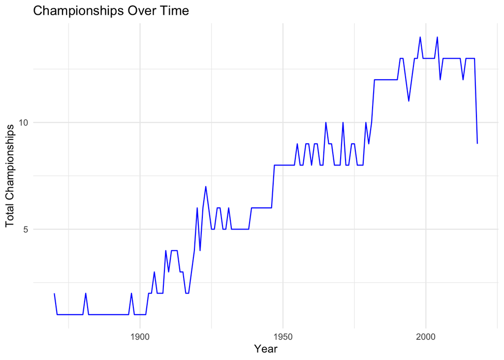

```r
source("Chart2.R")
```

This line chart shows the trend of championships won over the years, illustrating how the number of championships has changed over time. A notable observation I can make is that there were a total of two championships in 1870 and 9 total championships in 2018.

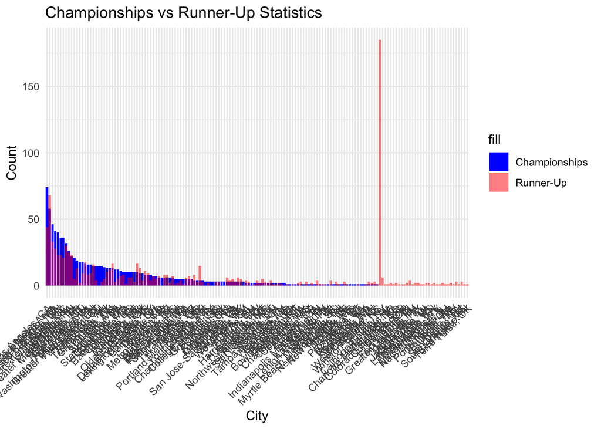

```r
source("Chart1.R")
```

This comparison chart shows the number of championships versus the number of runner-up finishes for each city. The purpose of this chart is to compare the competitive performance of cities beyond just championships, highlighting frequent near-wins. Notable observations I can make are that some cities have a high number of runner-up finishes compared to championships, indicating frequent near-wins. The comparison helps understand the competitiveness of cities beyond just championships.

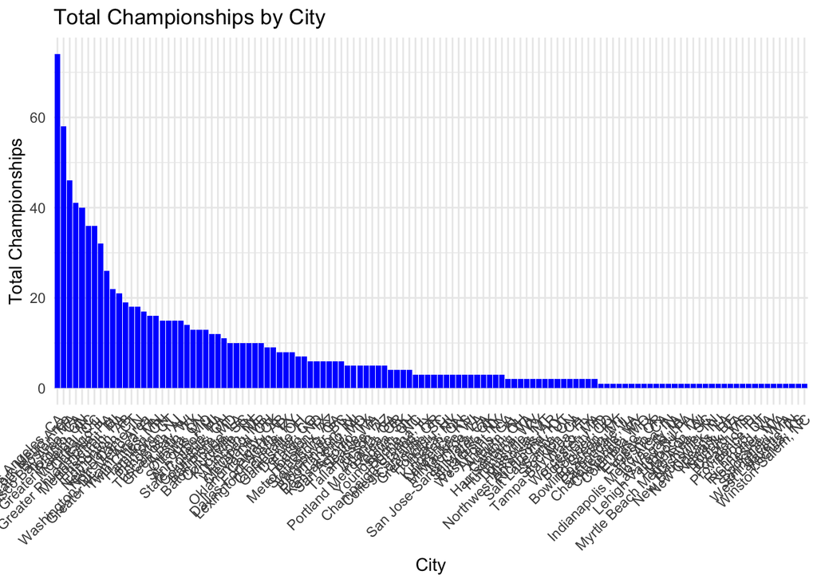

```r
source("Chart3.R")
```

This bar chart shows the total number of championships won by different cities. The purpose of this chart is to visualize which cities have the highest number of sports championships, indicating their dominance in various sports. Notable observations I can make are that Los Angeles has the highest number of championships and other cities like New York and Boston also have significant championship counts.